# Notebook

### Web Information Retrieval and Data Mining - Assignment 3

```
Student: PATRA, SUKANYA (1457357)
```

#### Answer 1.1, Baseline (4p)

- Dense network, at least 3 layers, shaped like a pyramid
  - Last layer: 10 nodes, sigmoid.
  - Loss: categorical cross-entropy. Metric: accuracy
- No preprocessing, regularization. Get at least 70% accuracy.
- Explain design decisions. Discuss performance.
  - Does it overfit (large/growing gap between loss and val_loss)?

[output not shown]

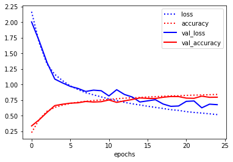

```
Model: "sequential"
_________________________________________________________________
Layer (type)                 Output Shape              Param #
=================================================================
reshape (Reshape)            (None, 3072)              0
_________________________________________________________________
dense (Dense)                (None, 512)               1573376
_________________________________________________________________
dense_1 (Dense)              (None, 256)               131328
_________________________________________________________________
dense_2 (Dense)              (None, 128)               32896
_________________________________________________________________
dense_3 (Dense)              (None, 64)                8256
_________________________________________________________________
dense_4 (Dense)              (None, 32)                2080
_________________________________________________________________
dense_5 (Dense)              (None, 10)                330
=================================================================
Total params: 1,748,266
Trainable params: 1,748,266
Non-trainable params: 0
_________________________________________________________________
None
def build_model_1_1():
  model_1_1 = models.Sequential()
  model_1_1.add(layers.Reshape((3072,), input_shape=(32,32,3)))
  model_1_1.add(layers.Dense(512, activation='relu'))
  model_1_1.add(layers.Dense(256, activation='relu'))
  model_1_1.add(layers.Dense(128, activation='relu'))
  model_1_1.add(layers.Dense(64, activation='relu'))
  model_1_1.add(layers.Dense(32, activation='relu'))
  model_1_1.add(layers.Dense(10, activation='softmax'))

  model_1_1.compile(optimizer='SGD',
                  loss='categorical_crossentropy',
                  metrics=['accuracy'])
  return model_1_1
```

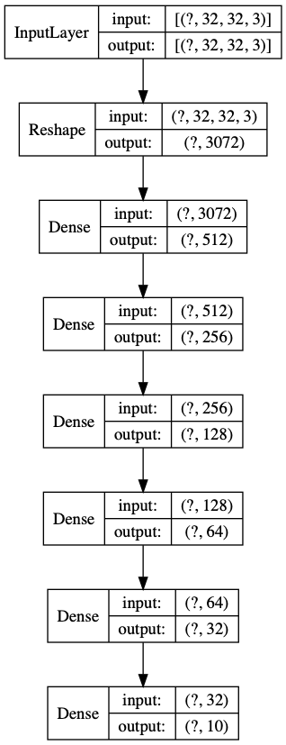

#### Answer 1.2, Preprocess (2p)

- Convert images to greyscale, other preprocessing optional.
  - Input shape should be (32,32,1)
- Explain design decisions. Is it better? Why (not)?
  - Color information is likely not so useful for classification. Greyscale makes the network smaller, less parameters to learn, less likely to overfit.

[output not shown]

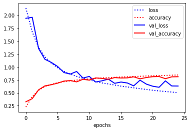

```
Model: "sequential_1"
_________________________________________________________________
Layer (type)                 Output Shape              Param #
=================================================================
reshape_1 (Reshape)          (None, 1024)              0
_________________________________________________________________
dense_6 (Dense)              (None, 512)               524800
_________________________________________________________________
dense_7 (Dense)              (None, 256)               131328
_________________________________________________________________
dense_8 (Dense)              (None, 128)               32896
_________________________________________________________________
dense_9 (Dense)              (None, 64)                8256
_________________________________________________________________
dense_10 (Dense)             (None, 32)                2080
_________________________________________________________________
dense_11 (Dense)             (None, 10)                330
=================================================================
Total params: 699,690
Trainable params: 699,690
Non-trainable params: 0
_________________________________________________________________
None
def build_model_1_2():
  model_1_2 = models.Sequential()
  model_1_2.add(layers.Reshape((1024,), input_shape=(32,32,1)))
  model_1_2.add(layers.Dense(512, activation='relu'))
  model_1_2.add(layers.Dense(256, activation='relu'))
  model_1_2.add(layers.Dense(128, activation='relu'))
  model_1_2.add(layers.Dense(64, activation='relu'))
  model_1_2.add(layers.Dense(32, activation='relu'))
  model_1_2.add(layers.Dense(10, activation='softmax'))
  model_1_2.compile(optimizer='SGD',
                  loss='categorical_crossentropy',
                  metrics=['accuracy'])
  return model_1_2
```

#### Answer 1.3, Tune (4p)

- Regularize the model. What works best?
  - Should consider batch normalization, dropout, l1/l2 regularization (or Nesterov)
- Tune other hyperparameters (e.g. learning rate, batch size,...) as you see fit.
  - At least consider tuning learning rate, ideally also momentum, decay, other optimizers
- Explain your findings and final design decisions. Discuss the results.
  - Should be better, at least it shouldn't overfit

[output not shown]

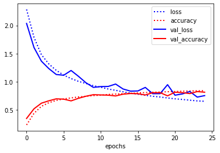

```
def build_model_1_3():
  model_1_3 = models.Sequential()
  model_1_3.add(layers.Reshape((1024,), input_shape=(32,32,1)))
  model_1_3.add(layers.Dense(512, activation='relu', kernel_regularizer=regularizers.l2(0.0001)))
  model_1_3.add(layers.Dense(256, activation='relu', kernel_regularizer=regularizers.l2(0.0001)))
  model_1_3.add(layers.Dense(128, activation='relu', kernel_regularizer=regularizers.l2(0.0001)))
  model_1_3.add(layers.Dense(64, activation='relu', kernel_regularizer=regularizers.l2(0.0001)))
  model_1_3.add(layers.Dense(32, activation='relu', kernel_regularizer=regularizers.l2(0.0001)))
  model_1_3.add(layers.Dense(10, activation='softmax', kernel_regularizer=regularizers.l2(0.0001)))

  model_1_3.compile(optimizer='SGD',
                  loss='categorical_crossentropy',
                  metrics=['accuracy'])
  return model_1_3
```

#### Answer 2.1, ConvNet (7p)

- Build a sequential ConvNet, get at least 90% accuracy.
  - Conv2D layers, input shape (32,32,1)
  - Consider using blocks of Conv2D layers with maxpooling in between
  - Use zero-padding in Conv2D layers because the images are small
  - At least one dense hidden layer and dense output layer (sigmoid)
  - Consider adding batch normalization, dropout
  - Consider small dropout rates in beginning, larger dropout rates later in network
  - Consider other optimizers and tuning learning rate, momentum,...
- Explain what you did and why (800 chars). Is it working well?
  - Should be quite elaborate and sensible

[output not shown]

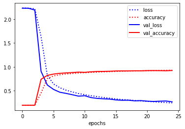

```
Model: "sequential_3"
_________________________________________________________________
Layer (type)                 Output Shape              Param #
=================================================================
conv2d (Conv2D)              (None, 32, 32, 32)        320
_________________________________________________________________
conv2d_1 (Conv2D)            (None, 30, 30, 32)        9248
_________________________________________________________________
max_pooling2d (MaxPooling2D) (None, 15, 15, 32)        0
_________________________________________________________________
dropout (Dropout)            (None, 15, 15, 32)        0
_________________________________________________________________
conv2d_2 (Conv2D)            (None, 13, 13, 64)        18496
_________________________________________________________________
conv2d_3 (Conv2D)            (None, 11, 11, 64)        36928
_________________________________________________________________
max_pooling2d_1 (MaxPooling2 (None, 5, 5, 64)          0
_________________________________________________________________
dropout_1 (Dropout)          (None, 5, 5, 64)          0
_________________________________________________________________
flatten (Flatten)            (None, 1600)              0
_________________________________________________________________
dense_18 (Dense)             (None, 128)               204928
_________________________________________________________________
dense_19 (Dense)             (None, 10)                1290
=================================================================
Total params: 271,210
Trainable params: 271,210
Non-trainable params: 0
_________________________________________________________________
None
def build_model_2_1():
  model_2_1 = models.Sequential()
  model_2_1.add(layers.Conv2D(32, (3, 3), activation='relu', padding='same', input_shape=(32, 32, 1)))
  model_2_1.add(layers.Conv2D(32, (3, 3), activation='relu'))
  model_2_1.add(layers.MaxPooling2D((2, 2)))
  model_2_1.add(layers.Dropout(0.2))
  model_2_1.add(layers.Conv2D(64, (3, 3), activation='relu'))
  model_2_1.add(layers.Conv2D(64, (3, 3), activation='relu'))
  model_2_1.add(layers.MaxPooling2D((2, 2)))
  model_2_1.add(layers.Dropout(0.3))
  model_2_1.add(layers.Flatten())
  model_2_1.add(layers.Dense(128, activation='relu'))
  model_2_1.add(layers.Dense(10, activation='softmax'))
  model_2_1.compile(optimizer='SGD',
              loss='categorical_crossentropy',
              metrics=['accuracy'])
  return model_2_1
```

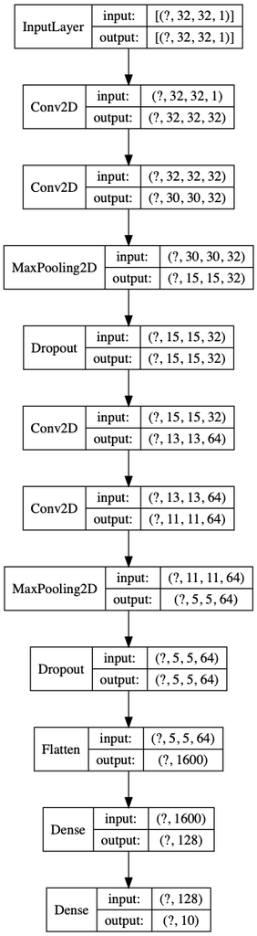

#### Answer 2.2, Data Augmentation (3p)

- Augment the preprocessed training data.
  - Use small variations (small shifts up-down, left-right) of flips becasue the images are small
  - Large shifts and rotations distort the image too much
- Explain what you did and why. Discuss the performance of the model.

[output not shown]

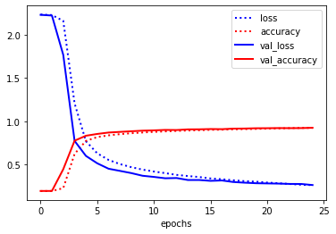

```
datagen = ImageDataGenerator(
    zoom_range=0.1,
    shear_range=0.8)
```

#### Answer 3.1, Misclassifications (2p)

[output not shown]

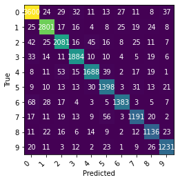

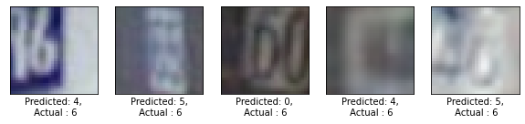

#### Answer 3.2, Activations (4p)

- Retrieve and visualize the activations for one example
- For every filter for different convolutional layers (at different depths in the network).
- Give an explanation. Is your model indeed learning something useful?
  - Should detect edges etc in first layers, higher-order object (e.g. interesting regions) in deeper layers.

[output not shown]

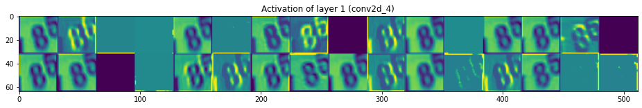

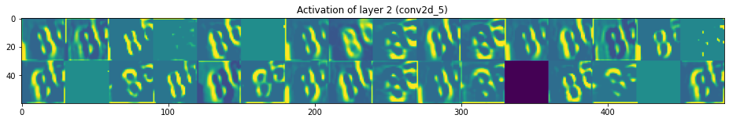

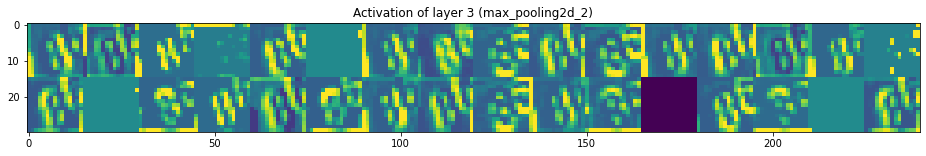

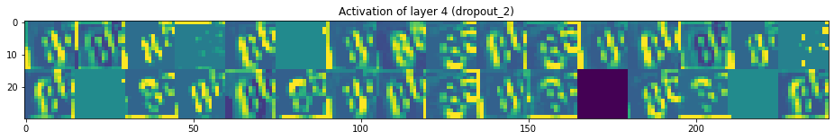

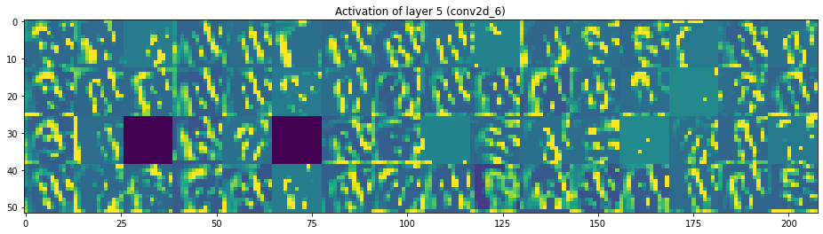

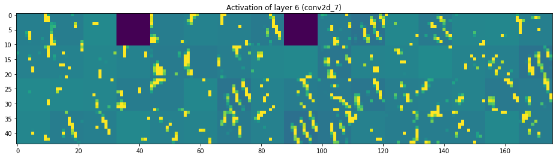

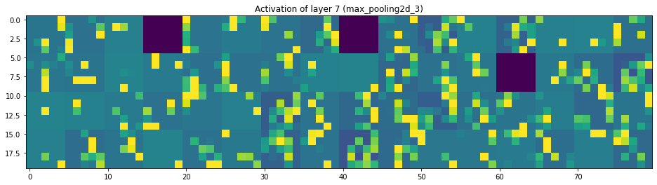

#### Answer 3.3, Class activation map (4p)

- Show a class activation map for your last convolutional layer
- Superimpose the activation map over the image, or plot side by side
  - Should make sense, detect interesting regions to classify the number

[figure not shown]

```
def plot_3_3():
  model = load_model_from_file(base_dir, "model_2_2")

  img_tensor = X_test_gray[0]
  img_tensor = np.expand_dims(img_tensor, axis=0)

  img_output = model.output[:]
  last_conv_layer = model.get_layer(index=5)

  grads = K.gradients(img_output, last_conv_layer.output)[0]
  #print(grads.shape)

  pooled_grads = K.mean(grads, axis=(0, 1, 2))
  iterate = K.function([model.input], [pooled_grads, last_conv_layer.output[0]])
  pooled_grads_value, conv_layer_output_value = iterate([img_tensor])


  for i in range(64):
      conv_layer_output_value[:, :, i] *= pooled_grads_value[i]

  heatmap = np.mean(conv_layer_output_value, axis=-1)
  heatmap = np.maximum(heatmap, 0)
  heatmap /= np.max(heatmap)
  #plt.matshow(heatmap)
  #plt.show()

  img = X_test[0]

  heatmap = cv2.resize(heatmap, (img.shape[1], img.shape[0]))
  heatmap = np.uint8(255 * heatmap)
  heatmap = cv2.applyColorMap(heatmap, cv2.COLORMAP_HOT)
  superimposed_img = heatmap * 0.01 + img
  RGB_im = cv2.cvtColor(np.uint8(superimposed_img), cv2.COLOR_BGR2RGB)

  fig, (ax1, ax2, ax3) = plt.subplots(1, 3)
  plt.rcParams['figure.dpi'] = 120

  ax1.imshow(img)
  ax2.imshow(heatmap)
  ax3.imshow(superimposed_img)
  ax1.set_xticks([])
  ax1.set_yticks([])
  ax2.set_xticks([])
  ax2.set_yticks([])
  ax3.set_xticks([])
  ax3.set_yticks([])
  ax1.set_xlabel('Input image')
  ax2.set_xlabel('Class activation map')
  ax3.set_xlabel('Superimposed Image')
  plt.show()
```

#### Answer 4.1, Fast feature extraction (5p)

- Import the VGG16 model, pretrained on ImageNet
- Freeze convolutional base, adds a dense layer
- Consider unfreezing the last few convolutional layers and evaluate whether that works better
  - Check if they do. It is very likely to help.
- Discuss the observed performance
  - Should get around 80% accuracy

[output not shown]

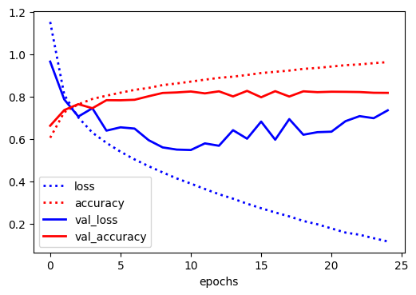

[output not shown]

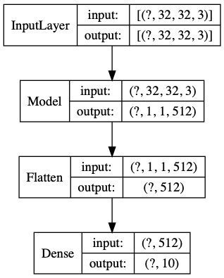

#### Answer 4.2, Embeddings (5p)

- Generate embeddings with the trained convolutional part of model_4_1 (without the dense layer)
- Embed the training and test data and store them to disk
- Build and evaluate a pipeline on the embedded data
  - Check if pipeline makes sense (e.g. use models that can handle many dimensions)
- Describe what you did and what you observed (max 800 chars).
  - Consider different models, preprocessing, tuning, etc.
  - Check performance (see original Submission.html) when in doubt. We did not run all the evaluations because it takes too long, and the output is ill-defined.

[output not shown]

```
Running time: 18.60 seconds
Last modified: May 26, 2020
scikit-learn version: 0.23.1
```